# Developing an AI application

Going forward, AI algorithms will be incorporated into more and more everyday applications. For example, you might want to include an image classifier in a smart phone app. To do this, you'd use a deep learning model trained on hundreds of thousands of images as part of the overall application architecture. A large part of software development in the future will be using these types of models as common parts of applications.

In this project, you'll train an image classifier to recognize different species of flowers. You can imagine using something like this in a phone app that tells you the name of the flower your camera is looking at. In practice you'd train this classifier, then export it for use in your application. We'll be using [this dataset](http://www.robots.ox.ac.uk/~vgg/data/flowers/102/index.html) of 102 flower categories, you can see a few examples below.

[figure not shown]

The project is broken down into multiple steps:

- Load and preprocess the image dataset
- Train the image classifier on your dataset
- Use the trained classifier to predict image content

We'll lead you through each part which you'll implement in Python.

When you've completed this project, you'll have an application that can be trained on any set of labeled images. Here your network will be learning about flowers and end up as a command line application. But, what you do with your new skills depends on your imagination and effort in building a dataset. For example, imagine an app where you take a picture of a car, it tells you what the make and model is, then looks up information about it. Go build your own dataset and make something new.

First up is importing the packages you'll need. It's good practice to keep all the imports at the beginning of your code. As you work through this notebook and find you need to import a package, make sure to add the import up here.

```python
# Imports here
%matplotlib inline
%config InlineBackend.figure_format = 'retina'

import os
import glob
import json
from datetime import datetime
from PIL import Image

import numpy as np
import matplotlib.pyplot as plt

import torch
from torch import nn, optim
import torch.nn.functional as F
from torchvision import datasets, transforms, models
```

## Load the data

Here you'll use `torchvision` to load the data ([documentation](http://pytorch.org/docs/0.3.0/torchvision/index.html)). The data should be included alongside this notebook, otherwise you can [download it here](https://s3.amazonaws.com/content.udacity-data.com/nd089/flower_data.tar.gz). The dataset is split into three parts, training, validation, and testing. For the training, you'll want to apply transformations such as random scaling, cropping, and flipping. This will help the network generalize leading to better performance. You'll also need to make sure the input data is resized to 224x224 pixels as required by the pre-trained networks.

The validation and testing sets are used to measure the model's performance on data it hasn't seen yet. For this you don't want any scaling or rotation transformations, but you'll need to resize then crop the images to the appropriate size.

The pre-trained networks you'll use were trained on the ImageNet dataset where each color channel was normalized separately. For all three sets you'll need to normalize the means and standard deviations of the images to what the network expects. For the means, it's `[0.485, 0.456, 0.406]` and for the standard deviations `[0.229, 0.224, 0.225]`, calculated from the ImageNet images. These values will shift each color channel to be centered at 0 and range from -1 to 1.

```python
data_dir = 'flowers'
train_dir = data_dir + '/train'
valid_dir = data_dir + '/valid'
test_dir = data_dir + '/test'
savedir = 'savechk'
```

```python
# Define normalization for all datasets
norm = transforms.Normalize(mean=[0.485, 0.456, 0.406], std=[0.229, 0.224, 0.225])

# Define a function to create transformations
def create_transform(resize, crop_size=224, randomize=False):
    transform_list = [transforms.Resize(resize), transforms.CenterCrop(crop_size)]
    if randomize:
        transform_list = [
            transforms.RandomRotation(30),
            transforms.RandomResizedCrop(crop_size),
            transforms.RandomHorizontalFlip()
        ] + transform_list[1:]  # Override Resize and CenterCrop with RandomResizedCrop

    transform_list.append(transforms.ToTensor())
    transform_list.append(norm)
    return transforms.Compose(transform_list)

# Create data transformations
data_transforms = {
    'train': create_transform(resize=256, randomize=True),
    'valid': create_transform(resize=256),
    'test': create_transform(resize=256)
}

# Load the datasets with ImageFolder
image_datasets = {x: datasets.ImageFolder(os.path.join(data_dir, x), transform=data_transforms[x])
                  for x in ['train', 'valid', 'test']}

# Define the dataloaders
dataloaders = {x: torch.utils.data.DataLoader(image_datasets[x], batch_size=64, shuffle=(x=='train'))
               for x in ['train', 'valid', 'test']}
```

### Label mapping

You'll also need to load in a mapping from category label to category name. You can find this in the file `cat_to_name.json`. It's a JSON object which you can read in with the [`json` module](https://docs.python.org/2/library/json.html). This will give you a dictionary mapping the integer encoded categories to the actual names of the flowers.

```python
import json

with open('cat_to_name.json', 'r') as f:
    cat_to_name = json.load(f)
```

# Building and training the classifier

Now that the data is ready, it's time to build and train the classifier. As usual, you should use one of the pretrained models from `torchvision.models` to get the image features. Build and train a new feed-forward classifier using those features.

We're going to leave this part up to you. Refer to [the rubric](https://review.udacity.com/#!/rubrics/1663/view) for guidance on successfully completing this section. Things you'll need to do:

- Load a [pre-trained network](http://pytorch.org/docs/master/torchvision/models.html) (If you need a starting point, the VGG networks work great and are straightforward to use)
- Define a new, untrained feed-forward network as a classifier, using ReLU activations and dropout
- Train the classifier layers using backpropagation using the pre-trained network to get the features
- Track the loss and accuracy on the validation set to determine the best hyperparameters

We've left a cell open for you below, but use as many as you need. Our advice is to break the problem up into smaller parts you can run separately. Check that each part is doing what you expect, then move on to the next. You'll likely find that as you work through each part, you'll need to go back and modify your previous code. This is totally normal!

When training make sure you're updating only the weights of the feed-forward network. You should be able to get the validation accuracy above 70% if you build everything right. Make sure to try different hyperparameters (learning rate, units in the classifier, epochs, etc) to find the best model. Save those hyperparameters to use as default values in the next part of the project.

One last important tip if you're using the workspace to run your code: To avoid having your workspace disconnect during the long-running tasks in this notebook, please read in the earlier page in this lesson called Intro to GPU Workspaces about Keeping Your Session Active. You'll want to include code from the workspace_utils.py module.

**Note for Workspace users:** If your network is over 1 GB when saved as a checkpoint, there might be issues with saving backups in your workspace. Typically this happens with wide dense layers after the convolutional layers. If your saved checkpoint is larger than 1 GB (you can open a terminal and check with `ls -lh`), you should reduce the size of your hidden layers and train again.

```python
# Setup the device
device = torch.device('cuda:0' if torch.cuda.is_available() else 'cpu')

# Arguments class for easy configuration
class Args:
    def __init__(self, arch='resnet18', hid=None, lrate=0.001, dpout=0.3, epochs=10, print_freq=40):
        self.arch = arch
        self.hid = hid
        self.lrate = lrate
        self.dpout = dpout
        self.epochs = epochs
        self.print_freq = print_freq

# Set up the arguments
args = Args()

# Supported input sizes for different architectures
in_size = {
    'densenet121': 1024,
    'densenet161': 2208,
    'vgg16': 25088,
}

# Default hidden sizes for different architectures
hid_size = {
    'densenet121': [500],
    'densenet161': [1000, 500],
    'vgg16': [4096, 4096, 1000],
}

# Function to build the classifier
def build_classifier(model, args):
    h_list = list(map(int, args.hid.split(','))) if args.hid else hid_size.get(args.arch, [])

    layers = [nn.Linear(in_size[args.arch], h_list[0]), nn.ReLU()]
    if 'vgg' in args.arch:
        layers.append(nn.Dropout(args.dpout))

    for i in range(len(h_list) - 1):
        layers += [nn.Linear(h_list[i], h_list[i+1]), nn.ReLU()]
        if 'vgg' in args.arch:
            layers.append(nn.Dropout(args.dpout))

    layers += [nn.Linear(h_list[-1], len(dataloaders['train'].dataset.classes)), nn.LogSoftmax(dim=1)]
    model.classifier = nn.Sequential(*layers)

    return model

# Function to validate the model
def validate(model, dataloader, criterion):
    model.eval()
    valid_loss = 0
    accuracy = 0

    with torch.no_grad():
        for images, labels in dataloader:
            images, labels = images.to(device), labels.to(device)
            output = model(images)
            valid_loss += criterion(output, labels).item()
            ps = torch.exp(output)
            equality = labels.data == ps.max(dim=1)[1]
            accuracy += equality.type(torch.FloatTensor).mean().item()

    return valid_loss / len(dataloader), accuracy / len(dataloader)

# Training function
def train(model, dataloaders, optimizer, criterion, epochs, print_freq):
    print(f'*** Training classifier on {"GPU" if torch.cuda.is_available() else "CPU"} ***\n')
    model.to(device)

    start_time = datetime.now()

    for epoch in range(epochs):
        model.train()
        running_loss = 0
        steps = 0

        for images, labels in dataloaders['train']:
            steps += 1
            images, labels = images.to(device), labels.to(device)

            optimizer.zero_grad()
            output = model(images)
            loss = criterion(output, labels)
            loss.backward()
            optimizer.step()

            running_loss += loss.item()

            if steps % print_freq == 0:
                valid_loss, accuracy = validate(model, dataloaders['valid'], criterion)
                print(f'Epoch {epoch+1}/{epochs}.. '
                      f'Training Loss: {running_loss/print_freq:.3f}.. '
                      f'Validation Loss: {valid_loss:.3f}.. '
                      f'Validation Accuracy: {accuracy*100:.2f}%')
                running_loss = 0

    elapsed = datetime.now() - start_time
    print(f'\n*** Classifier training completed! Elapsed time: {elapsed} ***')

    return model

# Load a pre-trained model and replace the classifier
model = models.__dict__[args.arch](pretrained=True)

# Freeze the model parameters
for param in model.parameters():
    param.requires_grad = False

# Build the classifier if needed
if args.arch == 'resnet18':
    model.fc = nn.Linear(model.fc.in_features, len(dataloaders['train'].dataset.classes))
else:
    model = build_classifier(model, args)

# Set criterion and optimizer
criterion = nn.CrossEntropyLoss() if args.arch == 'resnet18' else nn.NLLLoss()
optimizer = optim.Adam(model.fc.parameters() if args.arch == 'resnet18' else model.classifier.parameters(), lr=args.lrate)
```

```python
args.z_epochs = 10
args.z_print = 40
# Start training
model = train(model, dataloaders, optimizer, criterion, args.z_epochs, args.z_print)
```

[output not shown]

## Testing your network

It's good practice to test your trained network on test data, images the network has never seen either in training or validation. This will give you a good estimate for the model's performance on completely new images. Run the test images through the network and measure the accuracy, the same way you did validation. You should be able to reach around 70% accuracy on the test set if the model has been trained well.

```python
# TODO: Do validation on the test set
# Function to validate the model on the test set
def test(model, dataloaders, criterion, arch):
    print('*** Model architecture:', arch)
    print('*** Validating test set...\n')

    model.to(device)  # Ensure the model is on the right device
    model.eval()  # Set the model to evaluation mode

    test_loss = 0
    correct = 0
    total = 0

    start_time = datetime.now()

    with torch.no_grad():  # Disable gradient calculation
        for images, labels in dataloaders['test']:
            images, labels = images.to(device), labels.to(device)

            output = model(images)  # Forward pass
            test_loss += criterion(output, labels).item()  # Accumulate loss

            # Get predictions
            _, predicted = torch.max(output, 1)
            total += labels.size(0)
            correct += (predicted == labels).sum().item()

    # Calculate accuracy
    accuracy = (correct / total) * 100
    avg_test_loss = test_loss / len(dataloaders['test'])

    print(f'Test Loss: {avg_test_loss:.3f}')
    print(f'Test Accuracy: {accuracy:.2f}%')

    elapsed = datetime.now() - start_time
    print(f'\n*** Test validation done! Elapsed time: {elapsed}\n')

    return accuracy, avg_test_loss
```

```python
test(model, dataloaders, criterion, 'resnet18')
```

```
*** Model architecture: resnet18
*** Validating test set...

Test Loss: 0.370
Test Accuracy: 90.72%

*** Test validation done! Elapsed time: 0:00:47.150885
```

```
(90.72039072039072, 0.36958733201026917)
```

## Save the checkpoint

Now that your network is trained, save the model so you can load it later for making predictions. You probably want to save other things such as the mapping of classes to indices which you get from one of the image datasets: `image_datasets['train'].class_to_idx`. You can attach this to the model as an attribute which makes inference easier later on.

`model.class_to_idx = image_datasets['train'].class_to_idx`

Remember that you'll want to completely rebuild the model later so you can use it for inference. Make sure to include any information you need in the checkpoint. If you want to load the model and keep training, you'll want to save the number of epochs as well as the optimizer state, `optimizer.state_dict`. You'll likely want to use this trained model in the next part of the project, so best to save it now.

```python
# TODO: Save the checkpoint
# Function to save the model checkpoint
def save_checkpoint(model, dataloaders, args, savedir):
    # Move model to CPU
    model = model.cpu()

    # Prepare checkpoint dictionary
    checkpoint = {
        'arch': args.z_arch,
        'state_dict': model.state_dict(),
        'class_to_idx': dataloaders['train'].dataset.class_to_idx
    }

    # Add classifier or fc layer based on architecture
    if args.z_arch == 'resnet18':
        checkpoint['fc'] = model.fc.state_dict()  # Save state_dict of fc layer
    else:
        checkpoint['classifier'] = model.classifier.state_dict()  # Save state_dict of classifier

    # Create the save directory if it does not exist
    if not os.path.isdir(savedir):
        os.makedirs(savedir)

    # Construct checkpoint filename with timestamp
    chkpt_filename = datetime.now().strftime('%Y%m%d_%H%M') + '_' + args.z_arch + '.pth'
    chkpt_path = os.path.join(savedir, chkpt_filename)

    # Save the checkpoint
    torch.save(checkpoint, chkpt_path)
    print(f'*** Checkpoint saved: {chkpt_path}')

# Example usage
args.z_arch = 'resnet18'
save_checkpoint(model, dataloaders, args, savedir)
```

```
*** Checkpoint saved: savechk\20240903_2003_resnet18.pth
```

## Loading the checkpoint

At this point it's good to write a function that can load a checkpoint and rebuild the model. That way you can come back to this project and keep working on it without having to retrain the network.

```python
def load_checkpoint(filepath):
    # Load the checkpoint, forcing all tensors to be on CPU
    checkpoint = torch.load(filepath, map_location=lambda storage, loc: storage)

    # Initialize the model with the specified architecture
    model = models.__dict__[checkpoint['arch']](pretrained=True)

    # Update the model architecture-specific parts
    if checkpoint['arch'] == 'resnet18':
        model.fc = checkpoint['fc']
    else:
        model.classifier.load_state_dict(checkpoint['classifier'])

    # Load the model's state dictionary
    model.load_state_dict(checkpoint['state_dict'])

    # Set model class_to_idx
    model.class_to_idx = checkpoint['class_to_idx']

    return model
```

```python
# Load checkpoint if it exists
chkpt = datetime.now().strftime('%Y%m%d_%H%M') + '_' + args.z_arch + '.pth'
checkpt = os.path.join(savedir, chkpt)
if checkpt:
    # Load model and arguments from checkpoint
    model = load_checkpoint(checkpt)

    # Print the model architecture
    print('Model architecture:', args.z_arch, '\n')

    # Print details about the model's classifier or fully connected layer
    if args.z_arch == 'resnet18':
        print('Model fully connected layer (fc):\n', model.fc)
    else:
        print('Model classifier:\n', model.classifier)
else:
    print('\n*** Stop! No saved checkpoint found \n')

# List all attributes in args that start with 'z_'
print('Args list:\n', [attr for attr in dir(args) if attr.startswith('z_')])
```

[output not shown]

# Inference for classification

Now you'll write a function to use a trained network for inference. That is, you'll pass an image into the network and predict the class of the flower in the image. Write a function called `predict` that takes an image and a model, then returns the top $K$ most likely classes along with the probabilities. It should look like

```
probs, classes = predict(image_path, model)
print(probs)
print(classes)
> [ 0.01558163  0.01541934  0.01452626  0.01443549  0.01407339]
> ['70', '3', '45', '62', '55']
```

First you'll need to handle processing the input image such that it can be used in your network.

## Image Preprocessing

You'll want to use `PIL` to load the image ([documentation](https://pillow.readthedocs.io/en/latest/reference/Image.html)). It's best to write a function that preprocesses the image so it can be used as input for the model. This function should process the images in the same manner used for training.

First, resize the images where the shortest side is 256 pixels, keeping the aspect ratio. This can be done with the [`thumbnail`](http://pillow.readthedocs.io/en/3.1.x/reference/Image.html#PIL.Image.Image.thumbnail) or [`resize`](http://pillow.readthedocs.io/en/3.1.x/reference/Image.html#PIL.Image.Image.thumbnail) methods. Then you'll need to crop out the center 224x224 portion of the image.

Color channels of images are typically encoded as integers 0-255, but the model expected floats 0-1. You'll need to convert the values. It's easiest with a Numpy array, which you can get from a PIL image like so `np_image = np.array(pil_image)`.

As before, the network expects the images to be normalized in a specific way. For the means, it's `[0.485, 0.456, 0.406]` and for the standard deviations `[0.229, 0.224, 0.225]`. You'll want to subtract the means from each color channel, then divide by the standard deviation.

And finally, PyTorch expects the color channel to be the first dimension but it's the third dimension in the PIL image and Numpy array. You can reorder dimensions using [`ndarray.transpose`](https://docs.scipy.org/doc/numpy-1.13.0/reference/generated/numpy.ndarray.transpose.html). The color channel needs to be first and retain the order of the other two dimensions.

```python
def process_image(image):
    '''Scales, crops, and normalizes a PIL image for a PyTorch model,
       returns a Numpy array
    '''
    # Ensure image is in RGB mode
    if image.mode != 'RGB':
        image = image.convert('RGB')

    # Define constants
    target_size = 256
    crop_size = 224

    # Resize image while keeping aspect ratio
    width, height = image.size
    aspect_ratio = width / height
    if width < height:
        new_width = target_size
        new_height = int(new_width / aspect_ratio)
    else:
        new_height = target_size
        new_width = int(new_height * aspect_ratio)

    # Resize image
    image = image.resize((new_width, new_height))

    # Calculate margins for cropping
    left = (new_width - crop_size) / 2
    top = (new_height - crop_size) / 2
    right = (new_width + crop_size) / 2
    bottom = (new_height + crop_size) / 2

    # Crop the image
    image = image.crop((left, top, right, bottom))

    # Convert image to numpy array
    np_img = np.array(image)

    # Normalize image
    np_img = np_img / 255.0
    mean = np.array([0.485, 0.456, 0.406])
    std = np.array([0.229, 0.224, 0.225])
    np_img = (np_img - mean) / std

    # Transpose to (C, H, W) format
    np_img = np_img.transpose((2, 0, 1))

    return np_img
```

To check your work, the function below converts a PyTorch tensor and displays it in the notebook. If your `process_image` function works, running the output through this function should return the original image (except for the cropped out portions).

```python
def imshow(image, ax=None, title=None):
    """Imshow for Tensor."""
    if ax is None:
        fig, ax = plt.subplots()

    # PyTorch tensors assume the color channel is the first dimension
    # but matplotlib assumes is the third dimension
    image = image.numpy().transpose((1, 2, 0))

    # Undo preprocessing
    mean = np.array([0.485, 0.456, 0.406])
    std = np.array([0.229, 0.224, 0.225])
    image = std * image + mean

    # Image needs to be clipped between 0 and 1 or it looks like noise when displayed
    image = np.clip(image, 0, 1)

    ax.imshow(image)

    return ax
```

[output not shown]

[figure not shown]

```python
def pick_a_pic(dset_dir, dset_type, args, dataloaders):
    """ Randomly select an image file, its class, and path """

    # Ensure dataset directory and type are valid
    if not os.path.isdir(dset_dir):
        raise ValueError(f"Dataset directory {dset_dir} does not exist.")

    if dset_type not in dataloaders:
        raise ValueError(f"Dataset type {dset_type} not found in dataloaders.")

    # Randomly select a class and an image within that class
    args.z_imgcls = np.random.choice(dataloaders[dset_type].dataset.classes)
    class_dir = os.path.join(dset_dir, args.z_imgcls)

    if not os.path.isdir(class_dir):
        raise ValueError(f"Class directory {class_dir} does not exist.")

    args.z_rndimg = np.random.choice(os.listdir(class_dir))
    args.z_rndimgpth = os.path.join(class_dir, args.z_rndimg)

    return args

# Example usage
try:
    # Pick a random image from the test set
    args = pick_a_pic(test_dir, 'test', args, dataloaders)

    print('Class:', args.z_imgcls)
    print('Image:', args.z_rndimg)
    print('Path:', args.z_rndimgpth)
    print('Args parameters:\n', [i for i in dir(args) if i.startswith('z_')], '\n')

    # Process and display the image
    with Image.open(args.z_rndimgpth) as image:
        np_img = process_image(image)
        imshow(np_img)

    # Restore and display the original image
    with Image.open(args.z_rndimgpth) as image:
        plt.imshow(image)
        plt.title('Original Image')
        plt.show()

except Exception as e:
    print(f"An error occurred: {e}")
```

## Class Prediction

Once you can get images in the correct format, it's time to write a function for making predictions with your model. A common practice is to predict the top 5 or so (usually called top-$K$) most probable classes. You'll want to calculate the class probabilities then find the $K$ largest values.

To get the top $K$ largest values in a tensor use [`x.topk(k)`](http://pytorch.org/docs/master/torch.html#torch.topk). This method returns both the highest `k` probabilities and the indices of those probabilities corresponding to the classes. You need to convert from these indices to the actual class labels using `class_to_idx` which hopefully you added to the model or from an `ImageFolder` you used to load the data (see here). Make sure to invert the dictionary so you get a mapping from index to class as well.

Again, this method should take a path to an image and a model checkpoint, then return the probabilities and classes.

```
probs, classes = predict(image_path, model)
print(probs)
print(classes)
> [ 0.01558163  0.01541934  0.01452626  0.01443549  0.01407339]
> ['70', '3', '45', '62', '55']
```

```python
def predict(image_path, cat_to_name, arch, model, topk=5, device='cpu'):
    ''' Predict the class (or classes) of an image using a trained deep learning model.
    '''

    # Check if image file exists
    if not os.path.isfile(image_path):
        raise FileNotFoundError(f"Image file {image_path} does not exist.")

    model.to(device)
    model.eval()

    # Load and process the image
    pil_img = Image.open(image_path).convert('RGB')
    image = process_image(pil_img)
    image = torch.FloatTensor(image).unsqueeze(0)  # Add batch dimension

    image = image.to(device)

    # Perform prediction
    with torch.no_grad():
        output = model(image)

    # Calculate probabilities
    if arch == 'resnet18':
        ps = F.softmax(output, dim=1).squeeze()
    else:
        ps = torch.exp(output).squeeze()

    # Check if topk exceeds number of classes
    num_classes = ps.size(0)
    topk = min(topk, num_classes)

    # Get top k classes and probabilities
    topk_prob, topk_idx = ps.topk(topk)
    topk_probs = topk_prob.cpu().numpy()
    topk_idxs = topk_idx.cpu().numpy()

    # Map indices to class labels
    idx_class = {v: k for k, v in model.class_to_idx.items()}
    topk_classes = [idx_class[i] for i in topk_idxs]

    # Map class labels to class names
    topk_names = [cat_to_name[i] for i in topk_classes if i in cat_to_name]

    # Print results
    print(f'*** Top {topk} classes ***')
    print('Class names:   ', topk_names)
    print('Classes:       ', topk_classes)
    print('Probabilities: ', topk_probs)

    return topk_classes, topk_names, topk_probs
```

```python
# Pick a random image from the test set
args = pick_a_pic(test_dir, 'test', args, dataloaders)
```

```python
# Define the topk value
args.z_topk = 5

# Record the start time
start_time = datetime.now()

# Predict the topk classes and probabilities
topk_classes, topk_names, topk_probs = predict(args.z_rndimgpth, cat_to_name, args.z_arch, model, topk=args.z_topk)

# Calculate and print the elapsed time
elapsed = datetime.now() - start_time
print('\n*** Prediction elapsed time [hh:mm:ss.ms]: {}'.format(elapsed))

# Optionally, print results if needed
print('Top-k classes:', topk_classes)
print('Top-k names:', topk_names)
print('Top-k probabilities:', topk_probs)
```

```
*** Top 5 classes ***
Class names:    ['cyclamen', 'red ginger', 'fire lily', 'lotus lotus', 'garden phlox']
Classes:        ['88', '24', '21', '78', '32']
Probabilities:  [0.8416062  0.02924116 0.02426348 0.01800901 0.01014189]

*** Prediction elapsed time [hh:mm:ss.ms]: 0:00:00.078925
Top-k classes: ['88', '24', '21', '78', '32']
Top-k names: ['cyclamen', 'red ginger', 'fire lily', 'lotus lotus', 'garden phlox']
Top-k probabilities: [0.8416062  0.02924116 0.02426348 0.01800901 0.01014189]
```

## Sanity Checking

[figure not shown]

You can convert from the class integer encoding to actual flower names with the `cat_to_name.json` file (should have been loaded earlier in the notebook). To show a PyTorch tensor as an image, use the `imshow` function defined above.

```python
def show_classifier(model, imgcls, imgpth, arch, cat_to_name):
    ''' Display an image along with the top 5 predicted classes and their probabilities. '''

    # Predict the top classes and probabilities
    topk_classes, topk_names, topk_probs = predict(imgpth, cat_to_name, arch, model, topk=5)

    # Load the image
    img = Image.open(imgpth)

    # Get the image name
    img_name = cat_to_name.get(imgcls, "Unknown")

    # Create the figure and axes
    fig, (ax1, ax2) = plt.subplots(figsize=(10, 4), ncols=2)

    # Plot the image
    ax1.set_title(img_name)
    ax1.imshow(img)
    ax1.axis('off')

    # Plot the probabilities
    y_pos = np.arange(len(topk_probs))
    ax2.barh(y_pos, topk_probs)
    ax2.set_yticks(y_pos)
    ax2.set_yticklabels(topk_names)
    ax2.invert_yaxis()
    ax2.set_title('Class Probability')

    # Adjust layout
    plt.tight_layout()
    plt.show()
```

```
Image path: flowers/test\88\image_00474.jpg

*** Top 5 classes ***
Class names:    ['cyclamen', 'red ginger', 'fire lily', 'lotus lotus', 'garden phlox']
Classes:        ['88', '24', '21', '78', '32']
Probabilities:  [0.8416062  0.02924116 0.02426348 0.01800901 0.01014189]
```

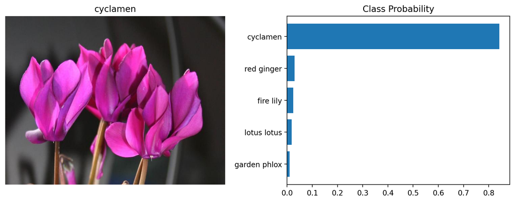

```python
# Display a randomly selected image with its top 5 class probabilities
print('Image path:', args.z_rndimgpth, '\n')

# Show the classifier output
show_classifier(model, args.z_imgcls, args.z_rndimgpth, args.z_arch, cat_to_name)
```